# Exploratory data analysis

### About events

We have said before that talkdesk is an event based service, being calls an event. Our database provides us the following information about this events:

1. total number of calls
2. total duration of this calls
3. total missing calls

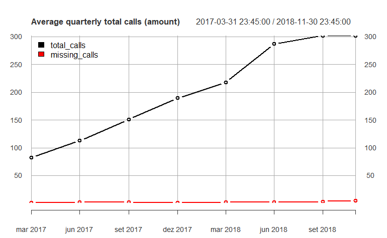

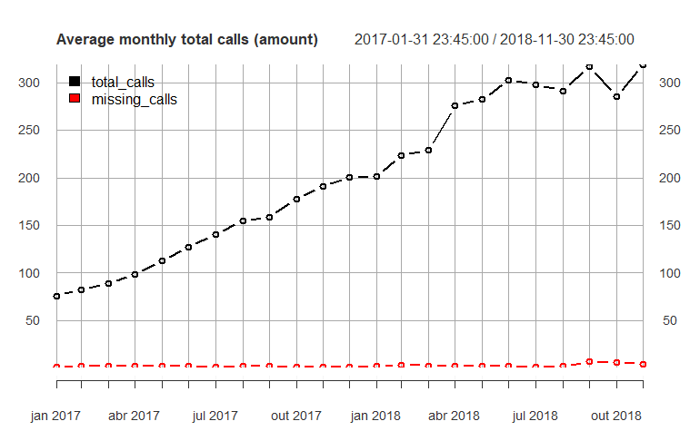

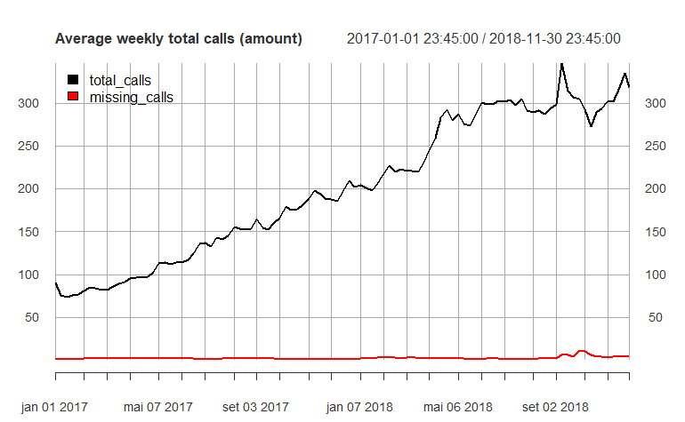

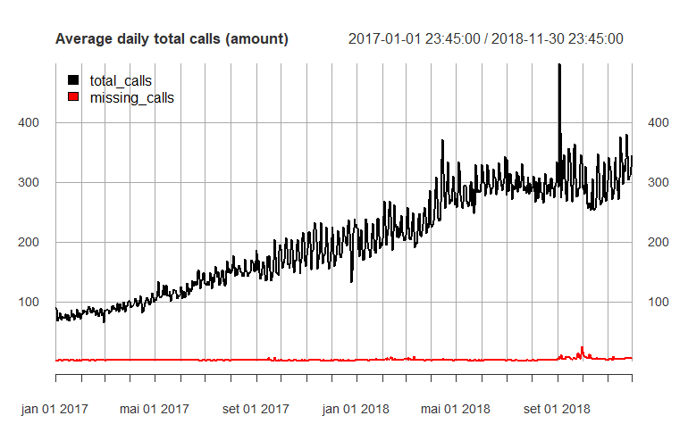

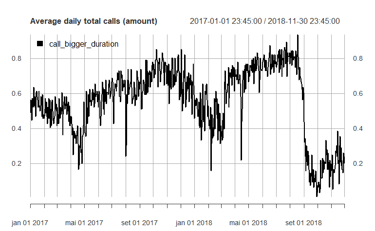

```r
# par(mfrow =c(2,1))
t <- xts_data
t$call_bigger_duration <- ifelse(t$total_calls_duration < t$on_a_call_time, 1,0)

plot.xts(period.apply(t[,"call_bigger_duration"],
                  on = "days",
                  INDEX = ep_days,
                  FUN = mean),
     type = "l",
     xlab = "Total calls",
     legend(c("total_calls","missing_calls")),
     legend.loc = "topleft",
     main = "Average daily total calls (amount)")
```

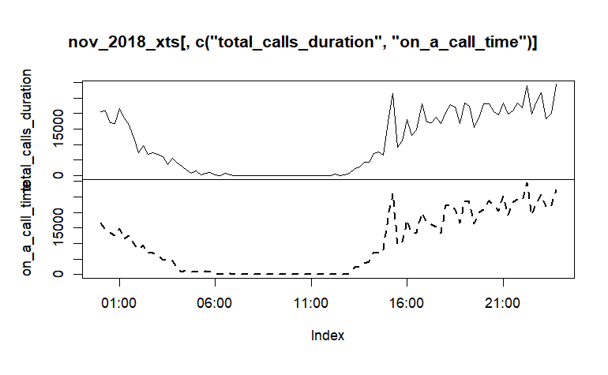

```r
nov_2018_xts = xts_data["2017-04-20"]
plot.zoo(nov_2018_xts[,c("total_calls_duration","on_a_call_time")],plot.type = "multiple", lty = c(1,2),lwd = c(1,2))
```

We expect total calls and its duration to be instrumental to find the right solutions. The total agent headcount depends on the amount of expected work which is triggered by the existence of events, in this case, calls.

**Plotting both the total number of calls and missing calls we notice a positive trend in time. That trend is not fully followed by missing calls which stay relatively flat during the period. Another noticible conclusion is that the variance increases with time and that the data is seasonal.**

Given that data is presented to us with 15 min time interval a daily seasonality was expected.

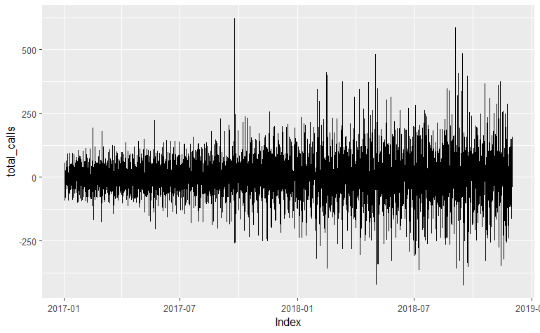

```r
autoplot(
  diff(xts_data$total_calls, lag = 96)[which(
    diff(xts_data$total_calls, lag = 96)$total_calls >= as.numeric(quantile(xts_data$total_calls,0.25))-1.5 * IQR(xts_data$total_calls) & diff(xts_data$total_calls, lag = 96)$total_calls <= as.numeric(quantile(xts_data$total_calls,0.75))+1.5 * IQR(xts_data$total_calls)
    ),]
  )
```

```r
Box.test(xts_data$total_calls, lag = 96, fitdf = 0, type = "Lj")
```

```
    Box-Ljung test

data:  xts_data$total_calls
X-squared = 1922800, df = 96, p-value < 2.2e-16
```

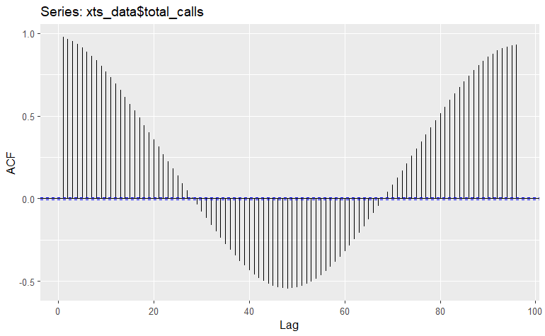

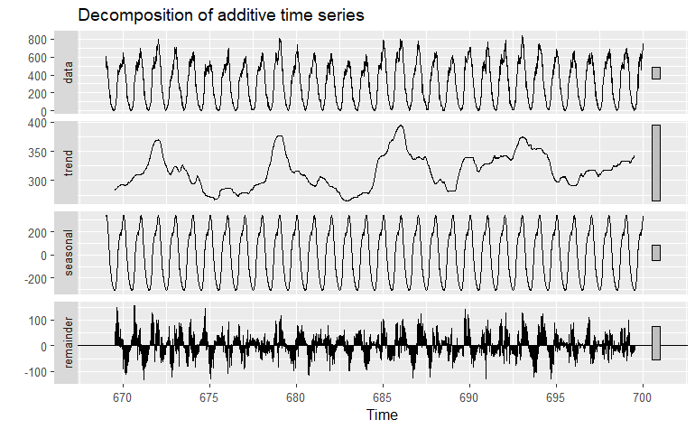

The above plots clearly display a daily seasonality as weel as weekly. By plotting quarterly and monthly we haven’t identify any source of seasonality.

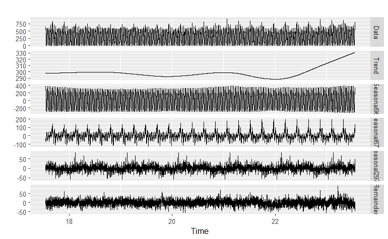

Lets now focus on the duration of this calls. In order to isolate the effect of increase number of calls we focus on call duration and search for a trend.

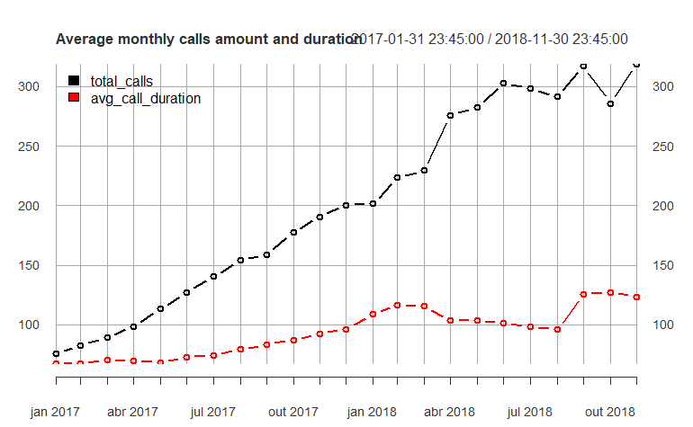

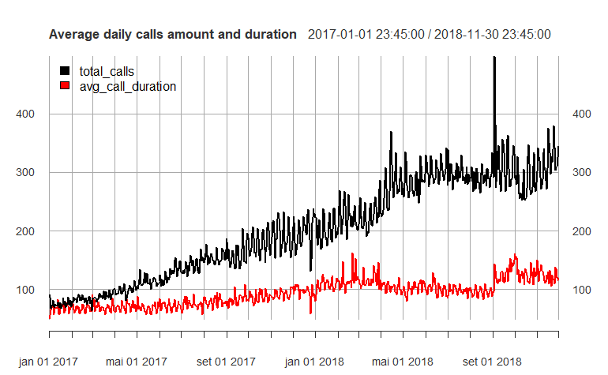

We notice that average call duration falls a positive trend as total calls, but at a lower slope.

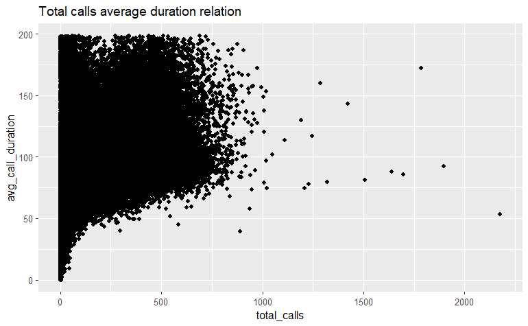

The scatter plot above further shows the lack of relationship between the total number of calls and its average duration.

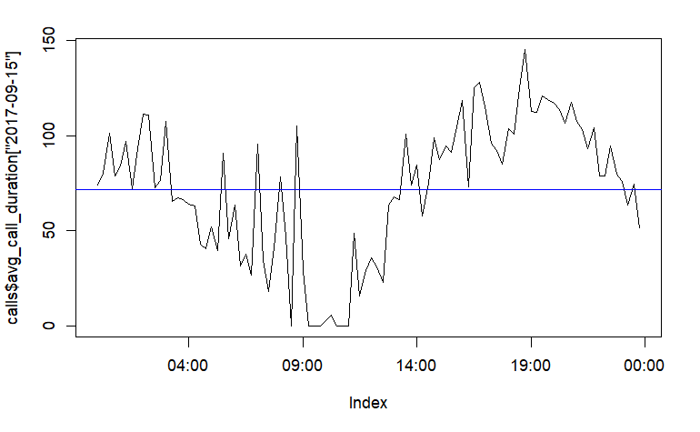

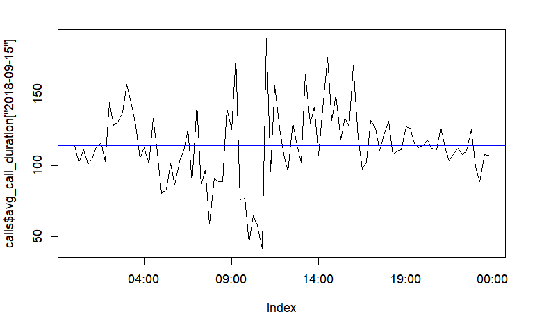

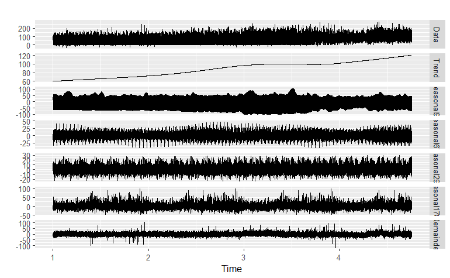

```r
msts_calls <- msts(calls, seasonal.periods = c(96,96*7,96*31,96*31*6))

msts_calls[,"avg_call_duration"] %>%
  #tail(96*31*6) %>%
  tsclean() %>%
  mstl() %>%
  autoplot()
```

Decomposing the trends we notice the existence of daily weekly, monthly and semester trends.

### Agents headcount

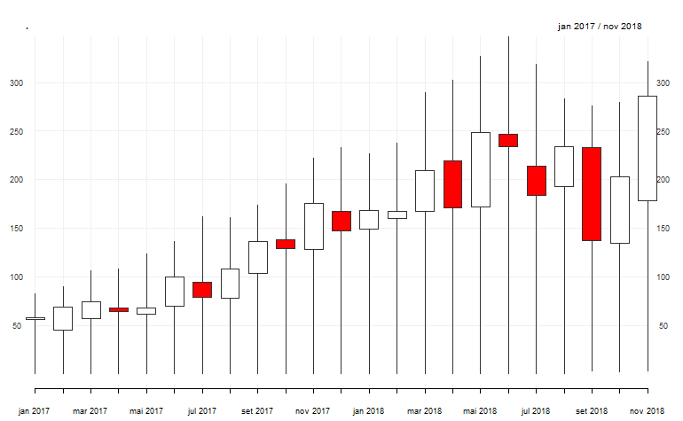

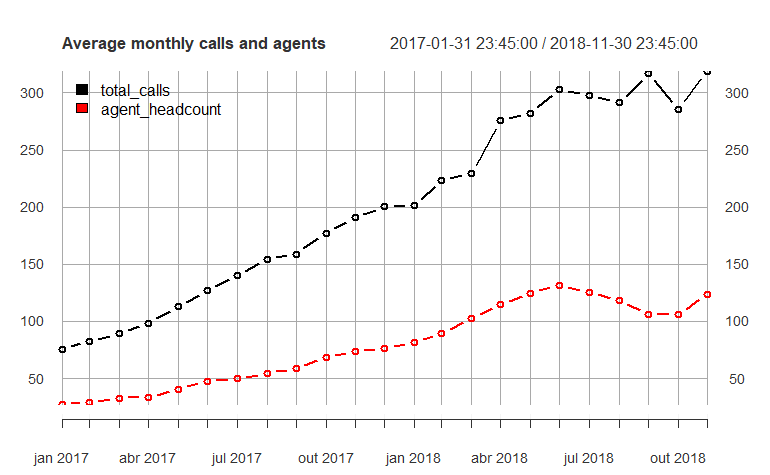

```r
plot(period.apply(xts_data[,c("total_calls","agent_headcount")],
                  on = "month",
                  INDEX = ep_months,
                  FUN = mean),
     type = "b",
     xlab = "months",
     legend(c("total_calls","agent_headcount")),
     legend.loc = "topleft",
     main = "Average monthly calls and agents")
```

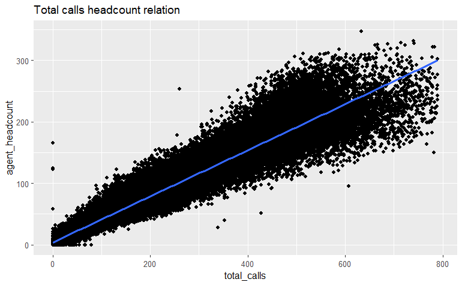

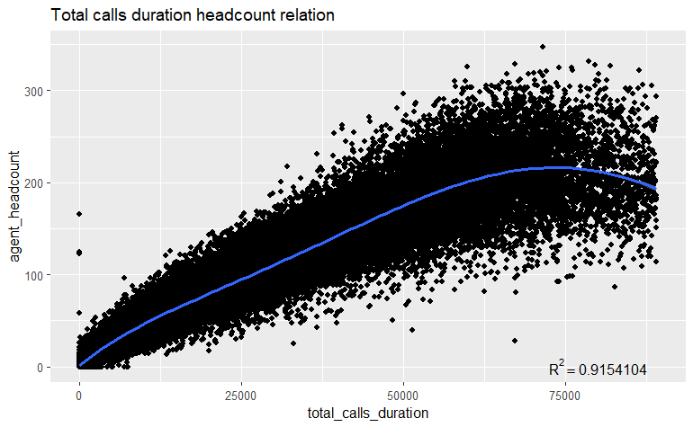

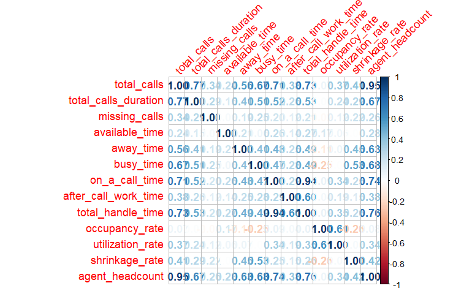

```r
corr <- cor(xts_data) %>% corrplot::corrplot(method = "number", tl.srt=45)
```

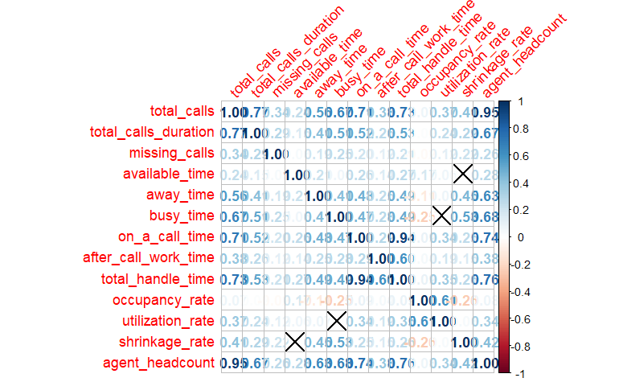

```r
# mat : is a matrix of data
# ... : further arguments to pass to the native R cor.test function
cor.mtest <- function(mat, ...) {
    mat <- as.matrix(mat)
    n <- ncol(mat)
    p.mat<- matrix(NA, n, n)
    diag(p.mat) <- 0
    for (i in 1:(n - 1)) {
        for (j in (i + 1):n) {
            tmp <- cor.test(mat[, i], mat[, j], ...)
            p.mat[i, j] <- p.mat[j, i] <- tmp$p.value
        }
    }
  colnames(p.mat) <- rownames(p.mat) <- colnames(mat)
  p.mat
}
# matrix of the p-value of the correlation
p.mat <- cor.mtest(xts_data)

corr <- cor(xts_data) %>% corrplot::corrplot(method = "number", tl.srt=45, p.mat = p.mat, sig.level = 0.05)
```

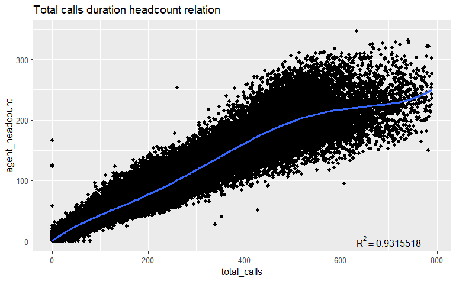

```r
as.data.frame(xts_data) %>%
  filter(total_calls > as.numeric(quantile(total_calls,0.25)) -  1.5 * IQR(total_calls) & total_calls < as.numeric(quantile(total_calls,0.75)) +  1.5 * IQR(total_calls)) %>%
  ggplot(aes(x = total_calls , y = agent_headcount)) +
  geom_point() +
  geom_smooth(formula = y ~ poly(x, 5, raw = TRUE),method = "lm") +
  labs(title = "Total calls duration headcount relation") +

  annotate("text",x = 700,y = 1,label = paste0("R^2 == ",summary(lm(agent_headcount ~  poly(total_calls, 5, raw = TRUE), data = xts_data))$adj.r.squared), parse =TRUE)
```

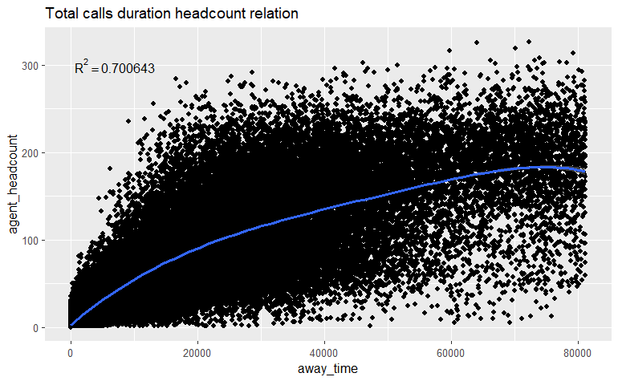

```r
as.data.frame(xts_data) %>%
  filter(away_time > as.numeric(quantile(away_time,0.25)) -  1.5 * IQR(away_time) & away_time < as.numeric(quantile(away_time,0.75)) +  1.5 * IQR(away_time)) %>%
  ggplot(aes(x = away_time , y = agent_headcount)) +
  geom_point() +
  geom_smooth(formula = y ~ poly(x, 5, raw = TRUE),method = "lm") +
  labs(title = "Total calls duration headcount relation") +

  annotate("text",x = 7000,y = 300,label = paste0("R^2 == ",summary(lm(agent_headcount ~  poly(away_time, 5, raw = TRUE), data = xts_data))$adj.r.squared), parse =TRUE)
```

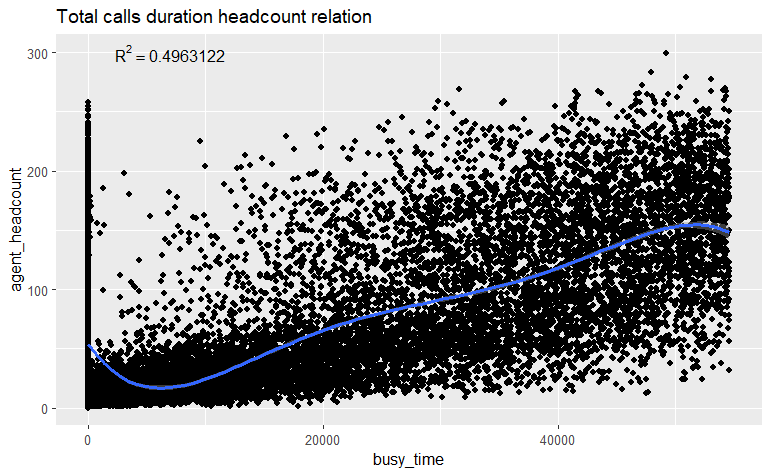

```r
as.data.frame(xts_data) %>%
  filter(busy_time > as.numeric(quantile(busy_time,0.25)) -  1.5 * IQR(busy_time) & busy_time < as.numeric(quantile(busy_time,0.75)) +  1.5 * IQR(busy_time)) %>%
  ggplot(aes(x = busy_time , y = agent_headcount)) +
  geom_point() +
  geom_smooth(formula = y ~ poly(x, 5, raw = TRUE),method = "lm") +
  labs(title = "Total calls duration headcount relation") +

  annotate("text",x = 7000,y = 300,label = paste0("R^2 == ",summary(lm(agent_headcount ~  poly(busy_time, 5, raw = TRUE), data = xts_data))$adj.r.squared), parse =TRUE)
```

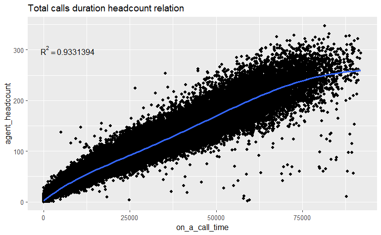

```r
as.data.frame(xts_data) %>%
  filter(on_a_call_time > as.numeric(quantile(on_a_call_time,0.25)) -  1.5 * IQR(on_a_call_time) & on_a_call_time < as.numeric(quantile(on_a_call_time,0.75)) +  1.5 * IQR(on_a_call_time)) %>%
  ggplot(aes(x = on_a_call_time , y = agent_headcount)) +
  geom_point() +
  geom_smooth(formula = y ~ poly(x, 5, raw = TRUE),method = "lm") +
  labs(title = "Total calls duration headcount relation") +

  annotate("text",x = 7000,y = 300,label = paste0("R^2 == ",summary(lm(agent_headcount ~  poly(on_a_call_time, 5, raw = TRUE), data = xts_data))$adj.r.squared), parse =TRUE)
```

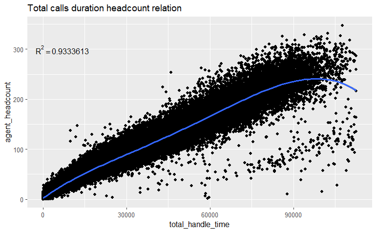

```r
as.data.frame(xts_data) %>%
  filter(total_handle_time > as.numeric(quantile(total_handle_time,0.25)) -  1.5 * IQR(total_handle_time) & total_handle_time < as.numeric(quantile(total_handle_time,0.75)) +  1.5 * IQR(total_handle_time)) %>%
  ggplot(aes(x = total_handle_time , y = agent_headcount)) +
  geom_point() +
  geom_smooth(formula = y ~ poly(x, 5, raw = TRUE),method = "lm") +
  labs(title = "Total calls duration headcount relation") +

  annotate("text",x = 7000,y = 300,label = paste0("R^2 == ",summary(lm(agent_headcount ~  poly(total_handle_time, 5, raw = TRUE), data = xts_data))$adj.r.squared), parse =TRUE)
```

[output not shown]

[output not shown]

[output not shown]

[output not shown]

[output not shown]